# Query MLB Database

Chien-Lan Hsueh

## Part 1 - Concepts

```python
# import modules used in this assignment
import numpy as np
import numpy.random as npr
import pandas as pd
import matplotlib.pyplot as plt
import sqlite3
from IPython.display import Markdown as md

# set seed
npr.seed()
```

### Question 1: Explain what the term sampling distribution means? What are sampling distributions used for.

**Ans:** A sample distribution is a probability distribution of randlomly sampled data drawn from a population. For example, we toll 10 dices in each sampling process and repeat this process for 10000 times. The propbability distribution of the obtained sampling data (ie. dice toll outcomes) is the sampling distribution. We use sample distribution to get statistical inference about the population. We can apply central limit theorem (CLT) on the sample distribution to get idea about the population's mean.

### Question 2: Simulation to investigate the sampling distribution

#### Sample size $n=10$

```
The first five samples: [array([ 0.46355937,  0.22461796,  0.87606899,  0.00861517,  2.16912984,
       -1.62629381,  1.35909387, -0.25714032,  2.63633617,  0.31507112]), array([ 0.9539131 ,  1.81802929, -1.08641004, -1.69047595, -0.23167007,
       -1.18464556,  0.43628018, -0.89896775, -0.50464069, -0.01637251]), array([ 2.08531645,  0.69661059,  1.10736303, -0.13263771, -1.01753158,
       -0.30854361, -0.14059543, -0.12359706, -0.94837739,  1.04863471]), array([-0.4726849 , -0.86030453,  0.11301095, -2.44165253,  0.64884378,
        0.44262341,  0.43054984,  0.2989215 ,  1.37039403, -0.48138376]), array([-0.49333501, -1.28324626, -0.97704459, -0.83467446,  2.0796688 ,
       -1.17057438,  0.84772755, -0.06886749,  0.41950108,  2.32180279])]
Variance of the first five samples: [1.35399348 1.0385263  0.87285575 0.98487746 1.54560777]
```

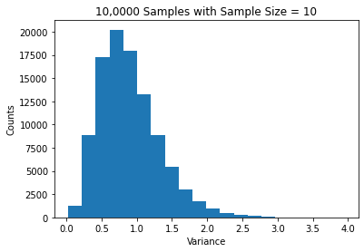

The probability of observing a sample variance larger than 2 is 1.856%.

```python
# get 10,0000 samples from the specified normal distribution with sample size of 10
samples_n10 = [npr.normal(loc = 0, scale = 1, size = 10) for _ in range(100000)]

# check the first 5 samples
print(f"The first five samples: {samples_n10[:5]}")

# get the variance
vars_n10 = np.var(samples_n10, axis = 1)

# check variance of the first 5 samples
print(f"Variance of the first five samples: {vars_n10[:5]}")

# plot a histogram of the sample variance
plt.hist(vars_n10, bins = 20)
plt.title("10,0000 Samples with Sample Size = 10")
plt.xlabel("Variance")
plt.ylabel("Counts")
plt.show()

# calculate the probability of samples with variance larger than 2
p_n10 = np.mean(vars_n10 > 2)
md(f"The probability of observing a sample variance larger than 2 is {p_n10 *100}%.")
```

#### Sample size $n=30$

```
The first five samples: [array([ 2.00191146,  0.61791189, -0.30043231,  0.13523032, -1.03361805,
        0.79536516, -0.22870186,  1.28485907,  0.34915948, -0.45108967,
        1.3985643 ,  0.1944107 , -0.91134847, -1.91067552,  0.58613568,
        0.98989971, -1.61293796, -2.76548706, -0.2276935 ,  0.25563741,
       -0.40072095, -1.52501024, -0.98878288, -0.29821202, -1.3478123 ,
       -0.6937095 ,  1.65703763,  0.99021397,  0.53905789, -0.40052206]), array([ 0.44980245,  0.51312135,  2.51443063, -1.84206391, -1.47371808,
        0.95526304, -0.30105646,  1.81235007,  0.49856243, -1.00596194,
       -0.05888345, -0.59923256, -0.1978847 ,  0.67045159, -0.71055545,
       -0.26819648, -2.13589306,  0.74999328, -1.02952499,  0.43820248,
       -0.44033579,  0.33882696, -0.55687472,  0.04674483,  1.05501799,
       -0.4642258 , -0.97929897,  0.7010555 ,  1.00814006,  0.1380592 ]), array([-0.39855828, -1.14774235, -0.52265395, -0.69729722,  0.73061086,
        0.51336723, -1.26917407,  0.55219253,  0.94310367,  0.49227881,
        0.06835461,  1.16378231,  0.1646098 ,  1.1068088 ,  0.22789368,
       -0.96192988, -0.09005645, -0.720079  , -0.39976066, -0.54668207,
        0.04897738,  1.14128044, -1.14345065,  1.58306158,  0.50048437,
        1.0749854 , -0.25370923, -0.5641537 ,  0.15143986, -1.33497547]), array([ 0.1705136 ,  0.33206773,  0.12245629,  0.05839825, -1.35997721,
        0.28300486, -0.07237627, -1.37816215, -1.3026501 , -0.28666908,
        2.16796908,  1.30416083, -0.15244345,  0.42030718,  1.18658291,
        0.42153793, -0.592317  , -1.18476468,  0.40027262, -1.03091698,
       -0.38640042,  0.20828618,  1.47100678,  2.10469479,  0.39631411,
       -0.3175723 ,  0.15577851,  0.47394883, -1.05961002, -0.35155225]), array([ 1.45687307,  1.26481612,  0.43333379, -0.228116  ,  0.55595358,
        1.29863318,  0.14661018, -1.17455154,  0.87594037, -0.87900985,
        0.56778545,  0.24728651, -1.10373099,  0.10678745, -0.77425366,
       -0.70260014, -0.62551237, -0.30072806, -1.17007343,  0.40022472,
        0.12602448, -0.27927847,  0.64248888, -1.36437559, -0.52562729,
       -0.89629243,  1.00254892,  0.82555596,  0.71670259,  0.2621513 ])]
Variance of the first five samples: [1.20191281 1.00467636 0.64535738 0.84376296 0.64351076]
```

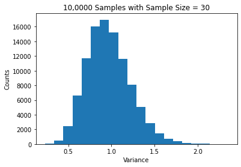

The probability of observing a sample variance larger than 2 is 0.059000000000000004%.

```python
# get 10,0000 samples from the specified normal distribution with sample size of 30
samples_n30 = [npr.normal(loc = 0, scale = 1, size = 30) for _ in range(100000)]

# check the first 5 samples
print(f"The first five samples: {samples_n30[:5]}")

# get the variance
vars_n30 = np.var(samples_n30, axis = 1)

# check variance of the first 5 samples
print(f"Variance of the first five samples: {vars_n30[:5]}")

# plot a histogram of the sample variance
plt.hist(vars_n30, bins = 20)
plt.title("10,0000 Samples with Sample Size = 30")
plt.xlabel("Variance")
plt.ylabel("Counts")
plt.show()

# calculate the probability of samples with variance larger than 2
p_n30 = np.mean(vars_n30 > 2)
md(f"The probability of observing a sample variance larger than 2 is {p_n30 *100}%.")
```

### Question 3: Respond to the following statement with reasoning for agreeing or disagreeing. "If you have a terabyte of data, you are working on big data."

**Ans:** One of the properties a big data has is its large size (volume). If data size is too big for us to work without using any new tools (software as well as hardware) and new skills, we will consider it a big data. Today, we might consider a terabyte of data as a big data. However, with advancement of hardware and development of new tools, this might not always be true in the future.

Beside the size, there are many other properties a big data has including how fast of the dataset changes and updates (velocity), diversed formats (variety) and uncertainties of the data (veracity). If the terabyte data exhibits any of these features, we can also consider it a big data.

### Question 4: What is meant by the acronym RDBMS?

**Ans:** RDMS stands for relational database management system which is a type of DBMS (database management system) that stores data in row-based tables with keys in the tables to define the relationship among them. Some examples of RDBMS include MySQL, Oracle, Microsoft SQLServer and PostgreSQL.

## Part 2 - Querying a database

### Task 1

Connect to the database and then look at all of the tables in the database.

This can be done by looking at the schema table in the database:

```python
# connect to the database
con = sqlite3.connect("lahman2016.sqlite")

# get info of all tables
df_tables = pd.read_sql("SELECT * FROM sqlite_schema WHERE type = 'table';", con)
df_tables
```

|  | type | name | tbl_name | rootpage | sql |
| --- | --- | --- | --- | --- | --- |
| 0 | table | AllstarFull | AllstarFull | 2 | CREATE TABLE AllstarFull (\nplayerID TEXT,\nye... |
| 1 | table | Appearances | Appearances | 3 | CREATE TABLE Appearances (\nyearID INTEGER,\nt... |
| 2 | table | AwardsManagers | AwardsManagers | 4 | CREATE TABLE AwardsManagers (\nplayerID TEXT,\... |
| 3 | table | AwardsPlayers | AwardsPlayers | 5 | CREATE TABLE AwardsPlayers (\nplayerID TEXT,\n... |
| 4 | table | AwardsShareManagers | AwardsShareManagers | 6 | CREATE TABLE AwardsShareManagers (\nawardID TE... |
| 5 | table | AwardsSharePlayers | AwardsSharePlayers | 9 | CREATE TABLE AwardsSharePlayers (\nawardID TEX... |
| 6 | table | Batting | Batting | 10 | CREATE TABLE Batting (\nplayerID TEXT,\nyearID... |
| 7 | table | BattingPost | BattingPost | 11 | CREATE TABLE BattingPost (\nyearID INTEGER,\nr... |
| 8 | table | CollegePlaying | CollegePlaying | 13 | CREATE TABLE CollegePlaying (\nplayerID TEXT,\... |
| 9 | table | Fielding | Fielding | 14 | CREATE TABLE Fielding (\nplayerID TEXT,\nyearI... |
| 10 | table | FieldingOF | FieldingOF | 15 | CREATE TABLE FieldingOF (\nplayerID TEXT,\nyea... |
| 11 | table | FieldingOFsplit | FieldingOFsplit | 16 | CREATE TABLE FieldingOFsplit (\nplayerID TEXT,... |
| 12 | table | FieldingPost | FieldingPost | 18 | CREATE TABLE FieldingPost (\nplayerID TEXT,\ny... |
| 13 | table | HallOfFame | HallOfFame | 19 | CREATE TABLE HallOfFame (\nplayerID TEXT,\nyea... |
| 14 | table | HomeGames | HomeGames | 20 | CREATE TABLE HomeGames (\nyearkey INTEGER,\nle... |
| 15 | table | Managers | Managers | 21 | CREATE TABLE Managers (\nplayerID TEXT,\nyearI... |
| 16 | table | ManagersHalf | ManagersHalf | 23 | CREATE TABLE ManagersHalf (\nplayerID TEXT,\ny... |
| 17 | table | Master | Master | 24 | CREATE TABLE Master (\nplayerID TEXT,\nbirthYe... |
| 18 | table | Parks | Parks | 25 | CREATE TABLE Parks (\nID INTEGER,\nparkalias T... |
| 19 | table | Pitching | Pitching | 26 | CREATE TABLE Pitching (\nplayerID TEXT,\nyearI... |
| 20 | table | PitchingPost | PitchingPost | 28 | CREATE TABLE PitchingPost (\nplayerID TEXT,\ny... |
| 21 | table | Salaries | Salaries | 29 | CREATE TABLE Salaries (\nyearID INTEGER,\nteam... |
| 22 | table | Schools | Schools | 30 | CREATE TABLE Schools (\nschoolID TEXT,\nname_f... |
| 23 | table | SeriesPost | SeriesPost | 32 | CREATE TABLE SeriesPost (\nyearID INTEGER,\nro... |
| 24 | table | Teams | Teams | 33 | CREATE TABLE Teams (\nyearID INTEGER,\nlgID TE... |
| 25 | table | TeamsFranchises | TeamsFranchises | 34 | CREATE TABLE TeamsFranchises (\nfranchID TEXT,... |
| 26 | table | TeamsHalf | TeamsHalf | 36 | CREATE TABLE TeamsHalf (\nyearID INTEGER,\nlgI... |

Before we continue, it's a good idea to quickly look at the tables (**Teams**, **HallOfFame**, **Managers**, **Pitching** and **Batting**) that we are going to use in the following tasks.

```python
# define SQL query template
sql_template = '''
	SELECT *
	FROM _table_;
	'''

# tables of interest
lst_tables = ["Teams", "HallOfFame", "Managers", "Pitching", "Batting"]

# read and get info of each table
for i in lst_tables:
    sql_query = sql_template.replace("_table_", i)

    # execute query and get the results
    df = pd.read_sql(sql_query, con)

    # print related info
    print(f"Table: {i}")
    print(f"Dimension: {df.shape}")
    print(f"Columns: {list(df.columns)}")
    display(df)
```

[output not shown]

|  | yearID | lgID | teamID | franchID | divID | Rank | G | Ghome | W | L | ... | DP | FP | name | park | attendance | BPF | PPF | teamIDBR | teamIDlahman45 | teamIDretro |
| --- | --- | --- | --- | --- | --- | --- | --- | --- | --- | --- | --- | --- | --- | --- | --- | --- | --- | --- | --- | --- | --- |
| 0 | 1871 | NA | BS1 | BNA | None | 3 | 31 | NaN | 20 | 10 | ... | NaN | 0.838 | Boston Red Stockings | South End Grounds I | NaN | 103 | 98 | BOS | BS1 | BS1 |
| 1 | 1871 | NA | CH1 | CNA | None | 2 | 28 | NaN | 19 | 9 | ... | NaN | 0.829 | Chicago White Stockings | Union Base-Ball Grounds | NaN | 104 | 102 | CHI | CH1 | CH1 |
| 2 | 1871 | NA | CL1 | CFC | None | 8 | 29 | NaN | 10 | 19 | ... | NaN | 0.814 | Cleveland Forest Citys | National Association Grounds | NaN | 96 | 100 | CLE | CL1 | CL1 |
| 3 | 1871 | NA | FW1 | KEK | None | 7 | 19 | NaN | 7 | 12 | ... | NaN | 0.803 | Fort Wayne Kekiongas | Hamilton Field | NaN | 101 | 107 | KEK | FW1 | FW1 |
| 4 | 1871 | NA | NY2 | NNA | None | 5 | 33 | NaN | 16 | 17 | ... | NaN | 0.839 | New York Mutuals | Union Grounds (Brooklyn) | NaN | 90 | 88 | NYU | NY2 | NY2 |
| ... | ... | ... | ... | ... | ... | ... | ... | ... | ... | ... | ... | ... | ... | ... | ... | ... | ... | ... | ... | ... | ... |
| 2830 | 2016 | NL | PIT | PIT | C | 3 | 162 | 81.0 | 78 | 83 | ... | 172.0 | 0.982 | Pittsburgh Pirates | PNC Park | 2249201.0 | 100 | 101 | PIT | PIT | PIT |
| 2831 | 2016 | NL | SDN | SDP | W | 5 | 162 | 81.0 | 68 | 94 | ... | 165.0 | 0.982 | San Diego Padres | Petco Park | 2351422.0 | 99 | 99 | SDP | SDN | SDN |
| 2832 | 2016 | NL | SFN | SFG | W | 2 | 162 | 81.0 | 87 | 75 | ... | 136.0 | 0.988 | San Francisco Giants | AT&T Park | 3365256.0 | 103 | 102 | SFG | SFN | SFN |
| 2833 | 2016 | NL | SLN | STL | C | 2 | 162 | 81.0 | 86 | 76 | ... | 169.0 | 0.983 | St. Louis Cardinals | Busch Stadium III | 3444490.0 | 100 | 99 | STL | SLN | SLN |
| 2834 | 2016 | NL | WAS | WSN | E | 1 | 162 | 81.0 | 95 | 67 | ... | 142.0 | 0.988 | Washington Nationals | Nationals Park | 2481938.0 | 100 | 98 | WSN | MON | WAS |

2835 rows × 48 columns

```
Table: HallOfFame
Dimension: (4156, 9)
Columns: ['playerID', 'yearid', 'votedBy', 'ballots', 'needed', 'votes', 'inducted', 'category', 'needed_note']
```

|  | playerID | yearid | votedBy | ballots | needed | votes | inducted | category | needed_note |
| --- | --- | --- | --- | --- | --- | --- | --- | --- | --- |
| 0 | aaronha01 | 1982 | BBWAA | 415.0 | 312.0 | 406.0 | Y | Player | None |
| 1 | abbotji01 | 2005 | BBWAA | 516.0 | 387.0 | 13.0 | N | Player | None |
| 2 | adamsba01 | 1937 | BBWAA | 201.0 | 151.0 | 8.0 | N | Player | None |
| 3 | adamsba01 | 1938 | BBWAA | 262.0 | 197.0 | 11.0 | N | Player | None |
| 4 | adamsba01 | 1939 | BBWAA | 274.0 | 206.0 | 11.0 | N | Player | None |
| ... | ... | ... | ... | ... | ... | ... | ... | ... | ... |
| 4151 | zachrpa01 | 1991 | BBWAA | 443.0 | 333.0 | 0.0 | N | Player | None |
| 4152 | zahnge01 | 1991 | BBWAA | 443.0 | 333.0 | 0.0 | N | Player | None |
| 4153 | zeileto01 | 2010 | BBWAA | 539.0 | 405.0 | 0.0 | N | Player | None |
| 4154 | zimmech01 | 1938 | BBWAA | 262.0 | 197.0 | 1.0 | N | Player | None |
| 4155 | ziskri01 | 1989 | BBWAA | 447.0 | 336.0 | 0.0 | N | Player | None |

4156 rows × 9 columns

```
Table: Managers
Dimension: (3436, 10)
Columns: ['playerID', 'yearID', 'teamID', 'lgID', 'inseason', 'G', 'W', 'L', 'rank', 'plyrMgr']
```

|  | playerID | yearID | teamID | lgID | inseason | G | W | L | rank | plyrMgr |
| --- | --- | --- | --- | --- | --- | --- | --- | --- | --- | --- |
| 0 | wrighha01 | 1871 | BS1 | NA | 1 | 31 | 20 | 10 | 3.0 | Y |
| 1 | woodji01 | 1871 | CH1 | NA | 1 | 28 | 19 | 9 | 2.0 | Y |
| 2 | paborch01 | 1871 | CL1 | NA | 1 | 29 | 10 | 19 | 8.0 | Y |
| 3 | lennobi01 | 1871 | FW1 | NA | 1 | 14 | 5 | 9 | 8.0 | Y |
| 4 | deaneha01 | 1871 | FW1 | NA | 2 | 5 | 2 | 3 | 8.0 | Y |
| ... | ... | ... | ... | ... | ... | ... | ... | ... | ... | ... |
| 3431 | mathemi01 | 2016 | SLN | NL | 1 | 162 | 86 | 76 | 2.0 | N |
| 3432 | cashke01 | 2016 | TBA | AL | 1 | 162 | 68 | 94 | 5.0 | N |
| 3433 | banisje01 | 2016 | TEX | AL | 1 | 162 | 95 | 67 | 1.0 | N |
| 3434 | gibbojo02 | 2016 | TOR | AL | 1 | 162 | 89 | 73 | 2.0 | N |
| 3435 | bakerdu01 | 2016 | WAS | NL | 1 | 162 | 95 | 67 | 1.0 | N |

3436 rows × 10 columns

```
Table: Pitching
Dimension: (44963, 30)
Columns: ['playerID', 'yearID', 'stint', 'teamID', 'lgID', 'W', 'L', 'G', 'GS', 'CG', 'SHO', 'SV', 'IPouts', 'H', 'ER', 'HR', 'BB', 'SO', 'BAOpp', 'ERA', 'IBB', 'WP', 'HBP', 'BK', 'BFP', 'GF', 'R', 'SH', 'SF', 'GIDP']
```

|  | playerID | yearID | stint | teamID | lgID | W | L | G | GS | CG | ... | IBB | WP | HBP | BK | BFP | GF | R | SH | SF | GIDP |
| --- | --- | --- | --- | --- | --- | --- | --- | --- | --- | --- | --- | --- | --- | --- | --- | --- | --- | --- | --- | --- | --- |
| 0 | aardsda01 | 2004 | 1 | SFN | NL | 1 | 0 | 11 | 0 | 0 | ... | 0.0 | 0.0 | 2.0 | 0 | 61.0 | 5.0 | 8 | 0.0 | 1.0 | 1.0 |
| 1 | aardsda01 | 2006 | 1 | CHN | NL | 3 | 0 | 45 | 0 | 0 | ... | 0.0 | 1.0 | 1.0 | 0 | 225.0 | 9.0 | 25 | 1.0 | 3.0 | 2.0 |
| 2 | aardsda01 | 2007 | 1 | CHA | AL | 2 | 1 | 25 | 0 | 0 | ... | 3.0 | 2.0 | 1.0 | 0 | 151.0 | 7.0 | 24 | 2.0 | 1.0 | 1.0 |
| 3 | aardsda01 | 2008 | 1 | BOS | AL | 4 | 2 | 47 | 0 | 0 | ... | 2.0 | 3.0 | 5.0 | 0 | 228.0 | 7.0 | 32 | 3.0 | 2.0 | 4.0 |
| 4 | aardsda01 | 2009 | 1 | SEA | AL | 3 | 6 | 73 | 0 | 0 | ... | 3.0 | 2.0 | 0.0 | 0 | 296.0 | 53.0 | 23 | 2.0 | 1.0 | 2.0 |
| ... | ... | ... | ... | ... | ... | ... | ... | ... | ... | ... | ... | ... | ... | ... | ... | ... | ... | ... | ... | ... | ... |
| 44958 | zuverge01 | 1957 | 1 | BAL | AL | 10 | 6 | 56 | 0 | 0 | ... | 13.0 | 1.0 | 4.0 | 0 | 475.0 | 37.0 | 37 | NaN | NaN | NaN |
| 44959 | zuverge01 | 1958 | 1 | BAL | AL | 2 | 2 | 45 | 0 | 0 | ... | 3.0 | 2.0 | 6.0 | 0 | 294.0 | 23.0 | 29 | NaN | NaN | NaN |
| 44960 | zuverge01 | 1959 | 1 | BAL | AL | 0 | 1 | 6 | 0 | 0 | ... | 0.0 | 1.0 | 0.0 | 0 | 55.0 | 1.0 | 7 | NaN | NaN | NaN |
| 44961 | zychto01 | 2015 | 1 | SEA | AL | 0 | 0 | 13 | 1 | 0 | ... | 0.0 | 1.0 | 2.0 | 0 | 76.0 | 4.0 | 6 | 0.0 | 0.0 | 0.0 |
| 44962 | zychto01 | 2016 | 1 | SEA | AL | 1 | 0 | 12 | 0 | 0 | ... | 2.0 | 0.0 | 1.0 | 0 | 60.0 | 3.0 | 6 | 0.0 | 1.0 | 1.0 |

44963 rows × 30 columns

```
Table: Batting
Dimension: (102816, 24)
Columns: ['playerID', 'yearID', 'stint', 'teamID', 'lgID', 'G', 'G_batting', 'AB', 'R', 'H', '2B', '3B', 'HR', 'RBI', 'SB', 'CS', 'BB', 'SO', 'IBB', 'HBP', 'SH', 'SF', 'GIDP', 'G_old']
```

|  | playerID | yearID | stint | teamID | lgID | G | G_batting | AB | R | H | ... | SB | CS | BB | SO | IBB | HBP | SH | SF | GIDP | G_old |
| --- | --- | --- | --- | --- | --- | --- | --- | --- | --- | --- | --- | --- | --- | --- | --- | --- | --- | --- | --- | --- | --- |
| 0 | aardsda01 | 2004 | 1 | SFN | NL | 11 | None | 0 | 0 | 0 | ... | 0.0 | 0.0 | 0 | 0.0 | 0.0 | 0.0 | 0.0 | 0.0 | 0.0 | None |
| 1 | aardsda01 | 2006 | 1 | CHN | NL | 45 | None | 2 | 0 | 0 | ... | 0.0 | 0.0 | 0 | 0.0 | 0.0 | 0.0 | 1.0 | 0.0 | 0.0 | None |
| 2 | aardsda01 | 2007 | 1 | CHA | AL | 25 | None | 0 | 0 | 0 | ... | 0.0 | 0.0 | 0 | 0.0 | 0.0 | 0.0 | 0.0 | 0.0 | 0.0 | None |
| 3 | aardsda01 | 2008 | 1 | BOS | AL | 47 | None | 1 | 0 | 0 | ... | 0.0 | 0.0 | 0 | 1.0 | 0.0 | 0.0 | 0.0 | 0.0 | 0.0 | None |
| 4 | aardsda01 | 2009 | 1 | SEA | AL | 73 | None | 0 | 0 | 0 | ... | 0.0 | 0.0 | 0 | 0.0 | 0.0 | 0.0 | 0.0 | 0.0 | 0.0 | None |
| ... | ... | ... | ... | ... | ... | ... | ... | ... | ... | ... | ... | ... | ... | ... | ... | ... | ... | ... | ... | ... | ... |
| 102811 | zwilldu01 | 1914 | 1 | CHF | FL | 154 | None | 592 | 91 | 185 | ... | 21.0 | NaN | 46 | 68.0 | NaN | 1.0 | 10.0 | NaN | NaN | None |
| 102812 | zwilldu01 | 1915 | 1 | CHF | FL | 150 | None | 548 | 65 | 157 | ... | 24.0 | NaN | 67 | 65.0 | NaN | 2.0 | 18.0 | NaN | NaN | None |
| 102813 | zwilldu01 | 1916 | 1 | CHN | NL | 35 | None | 53 | 4 | 6 | ... | 0.0 | NaN | 4 | 6.0 | NaN | 0.0 | 2.0 | NaN | NaN | None |
| 102814 | zychto01 | 2015 | 1 | SEA | AL | 13 | None | 0 | 0 | 0 | ... | 0.0 | 0.0 | 0 | 0.0 | 0.0 | 0.0 | 0.0 | 0.0 | 0.0 | None |
| 102815 | zychto01 | 2016 | 1 | SEA | AL | 12 | None | 0 | 0 | 0 | ... | 0.0 | 0.0 | 0 | 0.0 | 0.0 | 0.0 | 0.0 | 0.0 | 0.0 | None |

102816 rows × 24 columns

### Task 2

Write an SQL query that returns all the teams that played in the year 2015 with all of the corresponding columns from the Teams table. Turn the result into a data frame.

In the following tasks, we will always first define SQL query string for each task and use it to get the query result saved as a data frame. To get all rows of year 2015 from **Teams** table, we can use `WHERE` clause to filter `yearID`:

```python
# SQL query - all the teams that played in the year 2015
sql_query = '''
	SELECT *
	FROM Teams
	WHERE yearID = 2015;
	'''

# execute query and get the results
df = pd.read_sql(sql_query, con)
df
```

|  | yearID | lgID | teamID | franchID | divID | Rank | G | Ghome | W | L | ... | DP | FP | name | park | attendance | BPF | PPF | teamIDBR | teamIDlahman45 | teamIDretro |
| --- | --- | --- | --- | --- | --- | --- | --- | --- | --- | --- | --- | --- | --- | --- | --- | --- | --- | --- | --- | --- | --- |
| 0 | 2015 | AL | BAL | BAL | E | 3 | 162 | 78 | 81 | 81 | ... | 134 | 0.987 | Baltimore Orioles | Oriole Park at Camden Yards | 2281202 | 103 | 104 | BAL | BAL | BAL |
| 1 | 2015 | AL | BOS | BOS | E | 5 | 162 | 81 | 78 | 84 | ... | 148 | 0.984 | Boston Red Sox | Fenway Park II | 2880694 | 104 | 107 | BOS | BOS | BOS |
| 2 | 2015 | AL | CHA | CHW | C | 4 | 162 | 81 | 76 | 86 | ... | 159 | 0.983 | Chicago White Sox | U.S. Cellular Field | 1755810 | 92 | 93 | CHW | CHA | CHA |
| 3 | 2015 | AL | CLE | CLE | C | 3 | 161 | 80 | 81 | 80 | ... | 136 | 0.987 | Cleveland Indians | Progressive Field | 1388905 | 106 | 106 | CLE | CLE | CLE |
| 4 | 2015 | AL | DET | DET | C | 5 | 161 | 81 | 74 | 87 | ... | 165 | 0.986 | Detroit Tigers | Comerica Park | 2726048 | 97 | 98 | DET | DET | DET |
| 5 | 2015 | AL | HOU | HOU | W | 2 | 162 | 81 | 86 | 76 | ... | 131 | 0.986 | Houston Astros | Minute Maid Park | 2153585 | 97 | 99 | HOU | HOU | HOU |
| 6 | 2015 | AL | KCA | KCR | C | 1 | 162 | 81 | 95 | 67 | ... | 138 | 0.985 | Kansas City Royals | Kauffman Stadium | 2708549 | 104 | 103 | KCR | KCA | KCA |
| 7 | 2015 | AL | LAA | ANA | W | 3 | 162 | 81 | 85 | 77 | ... | 108 | 0.984 | Los Angeles Angels of Anaheim | Angel Stadium of Anaheim | 3012765 | 94 | 95 | LAA | ANA | ANA |
| 8 | 2015 | AL | MIN | MIN | C | 2 | 162 | 81 | 83 | 79 | ... | 150 | 0.986 | Minnesota Twins | Target Field | 2220054 | 103 | 104 | MIN | MIN | MIN |
| 9 | 2015 | AL | NYA | NYY | E | 2 | 162 | 81 | 87 | 75 | ... | 135 | 0.985 | New York Yankees | Yankee Stadium III | 3193795 | 99 | 101 | NYY | NYA | NYA |
| 10 | 2015 | AL | OAK | OAK | W | 5 | 162 | 81 | 68 | 94 | ... | 154 | 0.979 | Oakland Athletics | O.co Coliseum | 1768175 | 97 | 98 | OAK | OAK | OAK |
| 11 | 2015 | AL | SEA | SEA | W | 4 | 162 | 81 | 76 | 86 | ... | 155 | 0.985 | Seattle Mariners | Safeco Field | 2193581 | 92 | 94 | SEA | SEA | SEA |
| 12 | 2015 | AL | TBA | TBD | E | 4 | 162 | 84 | 80 | 82 | ... | 118 | 0.984 | Tampa Bay Rays | Tropicana Field | 1287054 | 100 | 102 | TBR | TBA | TBA |
| 13 | 2015 | AL | TEX | TEX | W | 1 | 162 | 81 | 88 | 74 | ... | 169 | 0.981 | Texas Rangers | Rangers Ballpark in Arlington | 2491875 | 102 | 105 | TEX | TEX | TEX |
| 14 | 2015 | AL | TOR | TOR | E | 1 | 162 | 81 | 93 | 69 | ... | 145 | 0.985 | Toronto Blue Jays | Rogers Centre | 2794891 | 99 | 98 | TOR | TOR | TOR |
| 15 | 2015 | NL | ARI | ARI | W | 3 | 162 | 81 | 79 | 83 | ... | 146 | 0.986 | Arizona Diamondbacks | Chase Field | 2080145 | 107 | 106 | ARI | ARI | ARI |
| 16 | 2015 | NL | ATL | ATL | E | 4 | 162 | 81 | 67 | 95 | ... | 186 | 0.985 | Atlanta Braves | Turner Field | 2001392 | 97 | 97 | ATL | ATL | ATL |
| 17 | 2015 | NL | CHN | CHC | C | 3 | 162 | 81 | 97 | 65 | ... | 120 | 0.982 | Chicago Cubs | Wrigley Field | 2919122 | 100 | 100 | CHC | CHN | CHN |
| 18 | 2015 | NL | CIN | CIN | C | 5 | 162 | 81 | 64 | 98 | ... | 131 | 0.985 | Cincinnati Reds | Great American Ball Park | 2419506 | 101 | 101 | CIN | CIN | CIN |
| 19 | 2015 | NL | COL | COL | W | 5 | 162 | 81 | 68 | 94 | ... | 171 | 0.985 | Colorado Rockies | Coors Field | 2506789 | 119 | 118 | COL | COL | COL |
| 20 | 2015 | NL | LAN | LAD | W | 1 | 162 | 81 | 92 | 70 | ... | 133 | 0.988 | Los Angeles Dodgers | Dodger Stadium | 3764815 | 101 | 98 | LAD | LAN | LAN |
| 21 | 2015 | NL | MIA | FLA | E | 3 | 162 | 81 | 71 | 91 | ... | 162 | 0.987 | Miami Marlins | Marlins Park | 1752235 | 98 | 97 | MIA | FLO | MIA |
| 22 | 2015 | NL | MIL | MIL | C | 4 | 162 | 81 | 68 | 94 | ... | 164 | 0.981 | Milwaukee Brewers | Miller Park | 2542558 | 101 | 101 | MIL | ML4 | MIL |
| 23 | 2015 | NL | NYN | NYM | E | 1 | 162 | 81 | 90 | 72 | ... | 131 | 0.986 | New York Mets | Citi Field | 2569753 | 94 | 92 | NYM | NYN | NYN |
| 24 | 2015 | NL | PHI | PHI | E | 5 | 162 | 81 | 63 | 99 | ... | 145 | 0.981 | Philadelphia Phillies | Citizens Bank Park | 1831080 | 98 | 98 | PHI | PHI | PHI |
| 25 | 2015 | NL | PIT | PIT | C | 2 | 162 | 81 | 98 | 64 | ... | 177 | 0.981 | Pittsburgh Pirates | PNC Park | 2498596 | 99 | 97 | PIT | PIT | PIT |
| 26 | 2015 | NL | SDN | SDP | W | 4 | 162 | 81 | 74 | 88 | ... | 138 | 0.985 | San Diego Padres | Petco Park | 2459742 | 98 | 97 | SDP | SDN | SDN |
| 27 | 2015 | NL | SFN | SFG | W | 2 | 162 | 81 | 84 | 78 | ... | 145 | 0.987 | San Francisco Giants | AT&T Park | 3375882 | 99 | 97 | SFG | SFN | SFN |
| 28 | 2015 | NL | SLN | STL | C | 1 | 162 | 81 | 100 | 62 | ... | 159 | 0.984 | St. Louis Cardinals | Busch Stadium III | 3520889 | 102 | 101 | STL | SLN | SLN |
| 29 | 2015 | NL | WAS | WSN | E | 2 | 162 | 81 | 83 | 79 | ... | 125 | 0.985 | Washington Nationals | Nationals Park | 2619843 | 102 | 99 | WSN | MON | WAS |

30 rows × 48 columns

### Task 3

Write an SQL query that returns all of the players in the hall of fame, the year they were voted into the hall of fame, and their category.

The **HallOfFame** table contains the voting data. We have to filter out the players who are inducted into the hall of fame by using a condition on `inducted` variable. Also use `SELECT` statement to get the variables of interest:

```python
# SQL query
sql_query = '''
	SELECT playerID, yearid, category
	FROM HallOfFame
	WHERE inducted = "Y";
	'''

# execute query and get the results
df = pd.read_sql(sql_query, con)
df
```

|  | playerID | yearid | category |
| --- | --- | --- | --- |
| 0 | aaronha01 | 1982 | Player |
| 1 | alexape01 | 1938 | Player |
| 2 | alomaro01 | 2011 | Player |
| 3 | alstowa01 | 1983 | Manager |
| 4 | andersp01 | 2000 | Manager |
| ... | ... | ... | ... |
| 312 | yastrca01 | 1989 | Player |
| 313 | yawketo99 | 1980 | Pioneer/Executive |
| 314 | youngcy01 | 1937 | Player |
| 315 | youngro01 | 1972 | Player |
| 316 | yountro01 | 1999 | Player |

317 rows × 3 columns

### Task 4

Write an SQL query that return all unique managers of the Pittsburgh Pirates (teamID of PIT) and only that information from the Managers table. Turn the result into a data frame.

Similar to the last task, but this time we use `SELECT DISTICT` statement to get unique values of `playerID` with `teamID = "PIT"` from **Managers** table:

```python
# SQL query
sql_query = '''
	SELECT DISTINCT playerID
	FROM Managers
	WHERE teamID = "PIT";
	'''

# execute query and get the results
df = pd.read_sql(sql_query, con)
display(df)

# report how many unique managers
md(f"There are {len(df)} unique managers of the Pittsburgh Pirates.")
```

|  | playerID |
| --- | --- |
| 0 | bezdehu99 |
| 1 | bragabo01 |
| 2 | buckeal99 |
| 3 | burnsto01 |
| 4 | burwebi01 |
| 5 | bushdo01 |
| 6 | callani01 |
| 7 | clarkfr01 |
| 8 | davissp01 |
| 9 | donovpa01 |
| 10 | dunlafr01 |
| 11 | ensje01 |
| 12 | friscfr01 |
| 13 | gibsoge01 |
| 14 | grammal01 |
| 15 | haneyfr01 |
| 16 | hanlone01 |
| 17 | heckegu01 |
| 18 | hermabi01 |
| 19 | hurdlcl01 |
| 20 | lamonge01 |
| 21 | leylaji99 |
| 22 | mackape01 |
| 23 | mackco01 |
| 24 | mcclell01 |
| 25 | mcgunbi01 |
| 26 | mckecbi01 |
| 27 | meyerbi01 |
| 28 | murtada01 |
| 29 | phillho99 |
| 30 | russejo02 |
| 31 | shepala99 |
| 32 | tannech01 |
| 33 | tracyji01 |
| 34 | traynpi01 |
| 35 | virdobi01 |
| 36 | wagneho01 |
| 37 | walkeha01 |
| 38 | watkibi01 |

There are 39 unique managers of the Pittsburgh Pirates.

### Task 5

Use SQL code and the HallOfFame and Managers tables to return all of the playerIDs for the people that managed for a team that were inducted into the hall of fame. Also, programmatically report the number of such people.

To get the hall of fame managers, we need to get **inner joint** portion of the **HallOfFame** and **Managers** tables, and then filter out those who are inducted with the condition `inducted = "Y"`:

```python
# SQL query
sql_query = '''
	SELECT l.playerID
 	FROM HallOfFame as l
    INNER JOIN Managers as r ON l.playerID = r.playerID
	WHERE l.inducted = "Y";
	'''

# execute query and get the results
df = pd.read_sql(sql_query, con)

# get the counts of each selected player
df2 = df.playerID.value_counts().reset_index().set_axis(["playerID", "Counts"], axis = 1)
display(df2)

# report how many unique Hall of Fame managers
md(f"There are {len(df2)} people that managed for a team that were inducted into the hall of fame.")
```

|  | playerID | Counts |
| --- | --- | --- |
| 0 | mackco01 | 53 |
| 1 | mcgrajo01 | 36 |
| 2 | larusto01 | 34 |
| 3 | coxbo01 | 29 |
| 4 | torrejo01 | 29 |
| ... | ... | ... |
| 88 | galvipu01 | 1 |
| 89 | applilu01 | 1 |
| 90 | maranra01 | 1 |
| 91 | bottoji01 | 1 |
| 92 | youngcy01 | 1 |

93 rows × 2 columns

There are 93 people that managed for a team that were inducted into the hall of fame.

### Task 6

Now use the same two tables and an SQL query to return every season managed by each manager that made it to the hall of fame. You should return the playerID (manager ID), G, W, and L columns from the Managers table.

Second, determine the overall win/loss records (sum of wins and sum of losses) for each of these hall of fame managers. Third, create a new variable that is the win/loss percentage (W/(W+L)). Lastly, sort the resulting data by the win/loss percentage variable (from largest to smallest).

To calculate each player's game statistics, we first group the data by player then do aggregation for the calculations and sorting:

```python
# SQL query
sql_query = '''
	SELECT r.yearID AS Year, l.playerID, r.G, r.W, r.L
    FROM HallOfFame as l
    INNER JOIN Managers as r ON l.playerID = r.playerID
	WHERE l.inducted = "Y";
	'''

# execute query and get the results
df = pd.read_sql(sql_query, con)
display(df)

# calculate overall win/loss and win/loss percentage for each hall of fame manager
df2 = df.groupby("playerID").agg(OveralWins = ("W", sum), OveralLosses = ("L", sum))
df2["WL_percentage"] = df2.OveralWins / (df2.OveralWins + df2.OveralLosses)

# sort the data by the win/loss percentage
df3 = df2.sort_values("WL_percentage", ascending = False)
df3
```

|  | Year | playerID | G | W | L |
| --- | --- | --- | --- | --- | --- |
| 0 | 1954 | alstowa01 | 154 | 92 | 62 |
| 1 | 1955 | alstowa01 | 154 | 98 | 55 |
| 2 | 1956 | alstowa01 | 154 | 93 | 61 |
| 3 | 1957 | alstowa01 | 154 | 84 | 70 |
| 4 | 1958 | alstowa01 | 154 | 71 | 83 |
| ... | ... | ... | ... | ... | ... |
| 969 | 1890 | wrighha01 | 46 | 22 | 23 |
| 970 | 1891 | wrighha01 | 138 | 68 | 69 |
| 971 | 1892 | wrighha01 | 155 | 87 | 66 |
| 972 | 1893 | wrighha01 | 133 | 72 | 57 |
| 973 | 1907 | youngcy01 | 6 | 3 | 3 |

974 rows × 5 columns

| playerID | OveralWins | OveralLosses | WL_percentage |
| --- | --- | --- | --- |
| wrighge01 | 59 | 25 | 0.702381 |
| spaldal01 | 78 | 47 | 0.624000 |
| mccarjo99 | 2125 | 1333 | 0.614517 |
| comisch01 | 840 | 541 | 0.608255 |
| seleefr99 | 1284 | 862 | 0.598322 |
| ... | ... | ... | ... |
| wallabo01 | 62 | 154 | 0.287037 |
| bottoji01 | 21 | 56 | 0.272727 |
| applilu01 | 10 | 30 | 0.250000 |
| wagneho01 | 1 | 4 | 0.200000 |
| connoro01 | 8 | 37 | 0.177778 |

93 rows × 3 columns

### Task 7

Using SQL, construct a table of hall of fame pitchers (any hall of famer that pitched) that gives the playerID and their total (sum) for GS, G, W, L, IPOuts, CG, SHO, and SV columns.

We will use **HallOfFame** and **Pitching** Tables to obtain the Hall of Fame pitchers before we calculate their statistics:

```python
# SQL query
sql_query = '''
	SELECT l.playerID, r.GS, r.G, r.W, r.L, r.IPOuts, r.CG, r.SHO, r.SV
    FROM HallOfFame as l
    INNER JOIN Pitching as r ON l.playerID = r.playerID
	WHERE l.inducted = "Y";
	'''

# execute query and get the results
df = pd.read_sql(sql_query, con)

# calculate overall sums of statistics of interets for each hall of fame pitcher
df_pitching = df.groupby("playerID").agg("sum")
display(df_pitching)

# report how many unique Hall of Fame pitchers
md(f"There are {len(df_pitching)} picther that are inducted into the hall of fame.")
```

| playerID | GS | G | W | L | IPouts | CG | SHO | SV |
| --- | --- | --- | --- | --- | --- | --- | --- | --- |
| alexape01 | 599 | 696 | 373 | 208 | 15570 | 437 | 90 | 32 |
| ansonca01 | 0 | 3 | 0 | 1 | 12 | 0 | 0 | 1 |
| becklja01 | 1 | 1 | 0 | 1 | 12 | 0 | 0 | 0 |
| bendech01 | 334 | 459 | 212 | 127 | 9051 | 255 | 40 | 34 |
| blylebe01 | 685 | 692 | 287 | 250 | 14910 | 242 | 60 | 0 |
| ... | ... | ... | ... | ... | ... | ... | ... | ... |
| willivi01 | 471 | 513 | 249 | 205 | 11988 | 388 | 50 | 11 |
| wrighge01 | 0 | 3 | 0 | 1 | 15 | 0 | 0 | 0 |
| wrighha01 | 7 | 34 | 4 | 4 | 298 | 0 | 0 | 8 |
| wynnea01 | 612 | 691 | 300 | 244 | 13692 | 290 | 49 | 15 |
| youngcy01 | 815 | 906 | 511 | 316 | 22064 | 749 | 76 | 17 |

101 rows × 8 columns

There are 101 picther that are inducted into the hall of fame.

### Task 8

For all of the hall of fame pitchers, use SQL to create a table of their batting statistics. Namely, the playerID and their total (sum) for AB, R, H, HR, RBI, BB, and SO.

The list of Hall of Fame pitcher is then left joined with **Batting** tables on `playerID` to get their batting data:

```python
# SQL query
sql_query = '''
	SELECT l.playerID, r2.AB, r2.R, r2.H, r2.HR, r2.RBI, r2.BB, r2.SO
    FROM HallOfFame as l
    INNER JOIN Pitching as r ON l.playerID = r.playerID
    LEFT JOIN Batting as r2 ON l.playerID = r2.playerID
	WHERE l.inducted = "Y";
	'''

# execute query and get the results
df = pd.read_sql(sql_query, con)

# calculate overall sums of statistics of interets for each hall of fame pitcher
df_batting = df.groupby("playerID").agg("sum")
display(df_batting)

# report how many unique Hall of Fame pitchers we can their batting data
md(f"There are {len(df_batting)} hall of fame picther that we get their batting data.")
```

| playerID | AB | R | H | HR | RBI | BB | SO |
| --- | --- | --- | --- | --- | --- | --- | --- |
| alexape01 | 38010 | 3234 | 7938 | 231 | 3423.0 | 1617 | 5796.0 |
| ansonca01 | 20554 | 3992 | 6836 | 194 | 4152.0 | 1966 | 604.0 |
| becklja01 | 9526 | 1600 | 2930 | 86 | 1575.0 | 616 | 270.0 |
| bendech01 | 18352 | 1632 | 3888 | 96 | 1856.0 | 1200 | 768.0 |
| blylebe01 | 10824 | 456 | 1416 | 0 | 600.0 | 120 | 4632.0 |
| ... | ... | ... | ... | ... | ... | ... | ... |
| willivi01 | 19409 | 1391 | 3224 | 13 | 1092.0 | 1053 | 104.0 |
| wrighge01 | 5750 | 1330 | 1734 | 22 | 660.0 | 134 | 238.0 |
| wrighha01 | 3264 | 732 | 888 | 16 | 444.0 | 144 | 48.0 |
| wynnea01 | 39192 | 3128 | 8395 | 391 | 3979.0 | 3243 | 7590.0 |
| youngcy01 | 68080 | 7475 | 14329 | 414 | 6670.0 | 1863 | 3450.0 |

101 rows × 7 columns

There are 101 hall of fame picther that we get their batting data

Check if the sets of `playerID` from the pitching and batting data are identical:

```python
# check if plyerID are the same in both data frames
set(df_pitching.index) == set(df_batting.index)
```

```
True
```

### Task 9

Using pandas to join the previous two tables together by pitcher.

Once we have the picting and batting data frames obtained in task 7 and 8, we can easily join them by using Pandas' merge() function:

```python
df = pd.merge(left=df_pitching, right=df_batting, how = "inner", on = "playerID")
df
```

| playerID | GS | G | W | L | IPouts | CG | SHO | SV | AB | R | H | HR | RBI | BB | SO |
| --- | --- | --- | --- | --- | --- | --- | --- | --- | --- | --- | --- | --- | --- | --- | --- |
| alexape01 | 599 | 696 | 373 | 208 | 15570 | 437 | 90 | 32 | 38010 | 3234 | 7938 | 231 | 3423.0 | 1617 | 5796.0 |
| ansonca01 | 0 | 3 | 0 | 1 | 12 | 0 | 0 | 1 | 20554 | 3992 | 6836 | 194 | 4152.0 | 1966 | 604.0 |
| becklja01 | 1 | 1 | 0 | 1 | 12 | 0 | 0 | 0 | 9526 | 1600 | 2930 | 86 | 1575.0 | 616 | 270.0 |
| bendech01 | 334 | 459 | 212 | 127 | 9051 | 255 | 40 | 34 | 18352 | 1632 | 3888 | 96 | 1856.0 | 1200 | 768.0 |
| blylebe01 | 685 | 692 | 287 | 250 | 14910 | 242 | 60 | 0 | 10824 | 456 | 1416 | 0 | 600.0 | 120 | 4632.0 |
| ... | ... | ... | ... | ... | ... | ... | ... | ... | ... | ... | ... | ... | ... | ... | ... |
| willivi01 | 471 | 513 | 249 | 205 | 11988 | 388 | 50 | 11 | 19409 | 1391 | 3224 | 13 | 1092.0 | 1053 | 104.0 |
| wrighge01 | 0 | 3 | 0 | 1 | 15 | 0 | 0 | 0 | 5750 | 1330 | 1734 | 22 | 660.0 | 134 | 238.0 |
| wrighha01 | 7 | 34 | 4 | 4 | 298 | 0 | 0 | 8 | 3264 | 732 | 888 | 16 | 444.0 | 144 | 48.0 |
| wynnea01 | 612 | 691 | 300 | 244 | 13692 | 290 | 49 | 15 | 39192 | 3128 | 8395 | 391 | 3979.0 | 3243 | 7590.0 |
| youngcy01 | 815 | 906 | 511 | 316 | 22064 | 749 | 76 | 17 | 68080 | 7475 | 14329 | 414 | 6670.0 | 1863 | 3450.0 |

101 rows × 15 columns